# Energy Transition Analysis

Asher Devine

2026-05-06

#### Overview

This R Markdown script analyzes the relationship between socioeconomic factors (income, partisanship) and energy production changes at the U.S. county level. It examines how renewable energy, CO2 emissions, and coal generation have changed over time and what factors correlate with those changes.

#### What This Script Does

- Combines Census/ACS income data, eGRID energy data, partisanship scores, CBSA (metro/micro/rural) classifications, and policy plan data
- Analyzes counties based on a configurable geography file
- Runs linear models with fixed effects for state, CBSA type, and policy plans
- Produces choropleth maps, scatter plots, correlation analyses, and distribution checks
- Excludes outlier counties (configurable in setup)

#### Required Data Files

Place these files in the working directory before running:

| File | Description |
| --- | --- |
| `geography.csv` | County FIPS codes to include in analysis (columns: fips, state) |
| `partisanship.csv` | County-level partisan index (columns: YEAR, STCOFIPS10, PARTISAN_INDEX_REP) |
| `hasplan.csv` | County-level policy plan scores (columns: fips, score) |
| `egrid files/eGRID{year}_data.xlsx` | EPA eGRID plant-level data (one file per year) |

#### Key Configuration Variables

All configurable settings are in Section 1 (Setup):

- `geography_file`: CSV file containing county list (default: “geography.csv”)
- `analysis_year`: Year for ACS and eGRID analysis (default: 2022)
- `egrid_change_baseline_year`: Baseline year for change calculations (default: 2012)
- `energy_vars`: Which energy variables to analyze (default: renewable_mwh, co2_tons, COAL)
- `excluded_counties`: FIPS codes to exclude from all analyses (outliers)

#### Output

- HTML report with all analyses, plots, and model results
- Console output with model summaries, correlations, and diagnostics
- Counties excluded from analysis are reported in the output

#### Notes

- eGRID Excel files must be closed while running (R cannot read open workbooks)
- Clear `census_cache` object or restart R if changing years
- Analysis requires stable internet connection for Census API calls
- Some chunks may take several minutes to run due to spatial operations

## 1. Setup

```r
#install.packages(c("tidycensus", "tidyverse", "sf", "tigris", "readxl", "janitor", "spdep", "ggplot2", "lme4", "emmeans"))

library(tidycensus)
library(tidyverse)
library(sf)
library(tigris)
library(readxl)
library(janitor)
library(spdep)
library(ggplot2)
library(lme4)
library(emmeans)

options(tigris_use_cache = TRUE)

geography_file <- "geography.csv"  # File with county list for selected geography

# CONFIGURE SUBREGION HERE
# Change this to analyze different subregions
#target_subregion <- "Central"

# CONFIGURE ANALYSIS YEAR HERE
# Change this to analyze different years (must be available in both ACS and eGRID)
analysis_year <- 2022

# Baseline year for change analysis (end year is analysis_year)
egrid_change_baseline_year <- 2012

# ENERGY VARIABLES (all three run in one knit)
#  - "renewable_mwh": change in renewable generation (MWh) (plgenacn + plgenabm)
#  - "co2_tons":      change in CO2 emissions (tons) (plco2an)
#  - "COAL":          change in generation from coal (MWh) (plgenacl)
energy_vars <- c("renewable_mwh", "co2_tons", "COAL")

# EXCLUDED COUNTIES (outliers for renewable_mwh analysis)
# These 4 counties are removed from all analyses due to extreme renewable energy increases
excluded_counties <- c("47143", "01083", "42079", "47065")

energy_label_for <- function(energy_var) {
  if (energy_var == "renewable_mwh") {
    "Change in renewable energy generation (MWh)"
  } else if (energy_var == "co2_tons") {
    "Change in annual CO2 emissions (tons)"
  } else {
    "Change in coal energy generation (MWh)"
  }
}
```

## 2. Load Geography Data

```r
geography_df <- read_csv(geography_file) |>
  clean_names() |>
#  filter(subregion == target_subregion) |>
  mutate(fips = str_pad(fips, 5, pad = "0")) |>
  filter(!fips %in% excluded_counties)
cat("Excluded counties from analysis:", paste(excluded_counties, collapse = ", "), "\n")
```

```
## Excluded counties from analysis: 47143, 01083, 42079, 47065
```

```r
cat("Remaining counties in geography_df:", nrow(geography_df), "\n")
```

```
## Remaining counties in geography_df: 419
```

## 3. Income Data (ACS)

We use median household income (B19013_001). Why two versions? Aligned (analysis_year): Matches eGRID data → best for correlation Lagged (analysis_year-2): Income precedes energy → tests robustness

ACS pulls are stored in `census_cache` so re-running chunks in the same R session does not repeat API calls (clear `census_cache` or restart R if you change `analysis_year`, `egrid_change_baseline_year`, or other ACS settings).

Metro/micro CBSA boundaries for section 9 are also fetched here.

```r
census_api_key("0b99bc09077560a4ae65416a235a4f0910a40637", install = FALSE)
```

```
## To install your API key for use in future sessions, run this function with `install = TRUE`.
```

```r
if (!exists("census_cache", envir = .GlobalEnv)) {
  assign("census_cache", new.env(parent = emptyenv()), envir = .GlobalEnv)
}

if (!exists("income_aligned", envir = census_cache, inherits = FALSE)) {
  income_analysis <- get_acs(
    geography = "county",
    variables = "B19013_001",
    year = analysis_year,
    survey = "acs5"
  ) |>
    select(GEOID, estimate) |>
    rename(median_income = estimate)

  income_baseline <- get_acs(
    geography = "county",
    variables = "B19013_001",
    year = egrid_change_baseline_year,
    survey = "acs5"
  ) |>
    select(GEOID, estimate) |>
    rename(median_income_baseline = estimate)

  assign(
    "income_aligned",
    income_analysis |>
      left_join(income_baseline, by = "GEOID") |>
      mutate(median_income_change = median_income - median_income_baseline),
    envir = census_cache
  )
}
if (!exists("income_lagged", envir = census_cache, inherits = FALSE)) {
  assign(
    "income_lagged",
    get_acs(
      geography = "county",
      variables = "B19013_001",
      year = analysis_year - 2,
      survey = "acs5"
    ) |>
      select(GEOID, estimate) |>
      rename(median_income = estimate),
    envir = census_cache
  )
}
if (!exists("cbsa_sf", envir = census_cache, inherits = FALSE)) {
  assign(
    "cbsa_sf",
    get_acs(
      geography = "metropolitan statistical area/micropolitan statistical area",
      variables = "B01001_001",
      year = analysis_year,
      survey = "acs5",
      geometry = TRUE
    ) |>
      st_transform(crs = 5070) |>
      mutate(
        cbsa_type = case_when(
          str_detect(NAME, "Metro Area") ~ "Metropolitan",
          str_detect(NAME, "Micro Area") ~ "Micropolitan",
          TRUE ~ NA_character_
        )
      ) |>
      select(cbsa_type),
    envir = census_cache
  )
}
income_aligned <- get("income_aligned", envir = census_cache)
income_lagged <- get("income_lagged", envir = census_cache)
cbsa_sf <- get("cbsa_sf", envir = census_cache)

# Restrict to selected geography
income_aligned_app <- income_aligned |>
  inner_join(geography_df, by = c("GEOID" = "fips"))

income_lagged_app <- income_lagged |>
  inner_join(geography_df, by = c("GEOID" = "fips"))
```

## 4. eGRID Data (Energy Change)

We load plant-level eGRID data for the baseline and analysis years, aggregate to county, and compute change for each entry in `energy_vars`. Workbooks live in `egrid files/` as `eGRID{year}_data.xlsx`. The plant sheet is either `PLNT{yy}` or `EGRDPLNT{yy}` (`yy` = last two digits of the year).

```r
load_egrid_year <- function(analysis_year, baseline_year, energy_var = c("renewable_mwh", "co2_tons", "COAL")) {
  energy_var <- match.arg(energy_var)

  # Read one year and normalize county FIPS.
  load_plants_for_year <- function(year, energy_var) {
    file_name <- file.path("egrid files", paste0("eGRID", year, "_data.xlsx"))
    sheets <- excel_sheets(file_name)
    yy <- sprintf("%02d", year %% 100)
    sheet_plnt <- paste0("PLNT", yy)
    sheet_egrd <- paste0("EGRDPLNT", yy)
    sheet_name <- if (sheet_plnt %in% sheets) {
      sheet_plnt
    } else if (sheet_egrd %in% sheets) {
      sheet_egrd
    } else {
      stop(
        "No plant sheet ", sheet_plnt, " or ", sheet_egrd, " in ", file_name,
        ". Available: ", paste(sheets, collapse = ", ")
      )
    }

    plants <- read_excel(file_name, sheet = sheet_name, skip = 1) |>
      clean_names() |>
      filter(!is.na(fipsst), !is.na(fipscnty)) |>
      mutate(
        fips = str_c(str_pad(fipsst, 2, pad = "0"), str_pad(fipscnty, 3, pad = "0"))
      )

    if (energy_var == "renewable_mwh") {
      plants <- plants |>
        mutate(energy_value = plgenacn + plgenabm)
    } else if (energy_var == "co2_tons") {
      plants <- plants |>
        mutate(energy_value = plco2an)
    } else if (energy_var == "COAL") {
      plants <- plants |>
        mutate(energy_value = plgenacl)
    }

    plants |>
      mutate(
        is_energy_producing = !is.na(plngenan) & plngenan > 0,
        energy_value = replace_na(energy_value, 0)
      ) |>
      group_by(fips) |>
      summarise(
        energy = sum(energy_value, na.rm = TRUE),
        is_energy_producing = any(is_energy_producing, na.rm = TRUE),
        .groups = "drop"
      )
  }

  county_baseline <- load_plants_for_year(baseline_year, energy_var)
  county_analysis <- load_plants_for_year(analysis_year, energy_var)

  producing_fips <- full_join(
    county_baseline |> select(fips, prod_base = is_energy_producing),
    county_analysis |> select(fips, prod_end = is_energy_producing),
    by = "fips"
  ) |>
    mutate(
      prod_base = replace_na(prod_base, FALSE),
      prod_end = replace_na(prod_end, FALSE),
      include_county = prod_base | prod_end
    ) |>
    filter(include_county) |>
    select(fips)

  county_change <- producing_fips |>
    left_join(
      county_baseline |>
        select(fips, energy_baseline = energy),
      by = "fips"
    ) |>
    left_join(
      county_analysis |>
        select(fips, energy_end = energy),
      by = "fips"
    ) |>
    mutate(
      energy_baseline = replace_na(energy_baseline, 0),
      energy_end = replace_na(energy_end, 0)
    ) |>
    mutate(energy_change = energy_end - energy_baseline)

  county_change
}

county_energy_by_var <- energy_vars |>
  set_names() |>
  map(function(ev) load_egrid_year(analysis_year, egrid_change_baseline_year, ev))
```

## 5. Build Analysis Datasets

For each energy variable, we use the corresponding `county_energy` (with `energy_change`) as the base dataset, then join income data.

```r
analysis_county_energy_by_var <- county_energy_by_var |>
  map(function(county_energy) {
    county_energy |>
      inner_join(
        income_aligned_app |>
          select(GEOID, median_income, median_income_change) |>
          rename(median_income_aligned = median_income),
        by = c("fips" = "GEOID")
      ) |>
      left_join(
        income_lagged_app |>
          select(GEOID, median_income) |>
          rename(median_income_lagged = median_income),
        by = c("fips" = "GEOID")
      )
  })

analysis_energy_change_by_var <- analysis_county_energy_by_var |>
  map(~ drop_na(.x, median_income_aligned, energy_change))
```

## 6. Change in energy variable vs median household income

For each entry in `energy_vars`, we take that eGRID metric at `egrid_change_baseline_year` and at `analysis_year`, compute county-level change inside `load_egrid_year()`, and work with the resulting `energy_change` column.

```r
walk(energy_vars, function(ev) {
  analysis_energy_change <- analysis_energy_change_by_var[[ev]]
  cat("\n============================\n")
  cat("CHANGE ANALYSIS [", ev, "]: (", sep = "")
  cat(
    egrid_change_baseline_year,
    " → ",
    analysis_year,
    ") vs median household income (ACS ",
    analysis_year,
    ", B19013_001)\n",
    sep = ""
  )
  cat("============================\n")

  cor_change <- cor.test(
    analysis_energy_change$median_income_aligned,
    analysis_energy_change$energy_change,
    method = "pearson"
  )
  print(cor_change)

  model_change <- lm(energy_change ~ median_income_aligned, data = analysis_energy_change)
  print(summary(model_change))
})
```

```
##
## ============================
## CHANGE ANALYSIS [renewable_mwh]: (2012 → 2022) vs median household income (ACS 2022, B19013_001)
## ============================
##
##  Pearson's product-moment correlation
##
## data:  analysis_energy_change$median_income_aligned and analysis_energy_change$energy_change
## t = -0.034417, df = 218, p-value = 0.9726
## alternative hypothesis: true correlation is not equal to 0
## 95 percent confidence interval:
##  -0.1345609  0.1299805
## sample estimates:
##          cor
## -0.002330976
##
##
## Call:
## lm(formula = energy_change ~ median_income_aligned, data = analysis_energy_change)
##
## Residuals:
##     Min      1Q  Median      3Q     Max
## -447158  -53452  -48200   -7338  688340
##
## Coefficients:
##                         Estimate Std. Error t value Pr(>|t|)
## (Intercept)            5.511e+04  5.366e+04   1.027    0.306
## median_income_aligned -3.123e-02  9.073e-01  -0.034    0.973
##
## Residual standard error: 142200 on 218 degrees of freedom
## Multiple R-squared:  5.433e-06,  Adjusted R-squared:  -0.004582
## F-statistic: 0.001184 on 1 and 218 DF,  p-value: 0.9726
##
##
## ============================
## CHANGE ANALYSIS [co2_tons]: (2012 → 2022) vs median household income (ACS 2022, B19013_001)
## ============================
##
##  Pearson's product-moment correlation
##
```

[output cut: 43 more lines]

```
## Call:
## lm(formula = energy_change ~ median_income_aligned, data = analysis_energy_change)
##
## Residuals:
##       Min        1Q    Median        3Q       Max
## -17899644    455271    636423    754564   4341206
##
## Coefficients:
##                        Estimate Std. Error t value Pr(>|t|)
## (Intercept)           384226.82  889186.68   0.432    0.666
## median_income_aligned    -19.00      15.03  -1.264    0.208
##
## Residual standard error: 2357000 on 218 degrees of freedom
## Multiple R-squared:  0.007275,   Adjusted R-squared:  0.002721
## F-statistic: 1.597 on 1 and 218 DF,  p-value: 0.2076
```

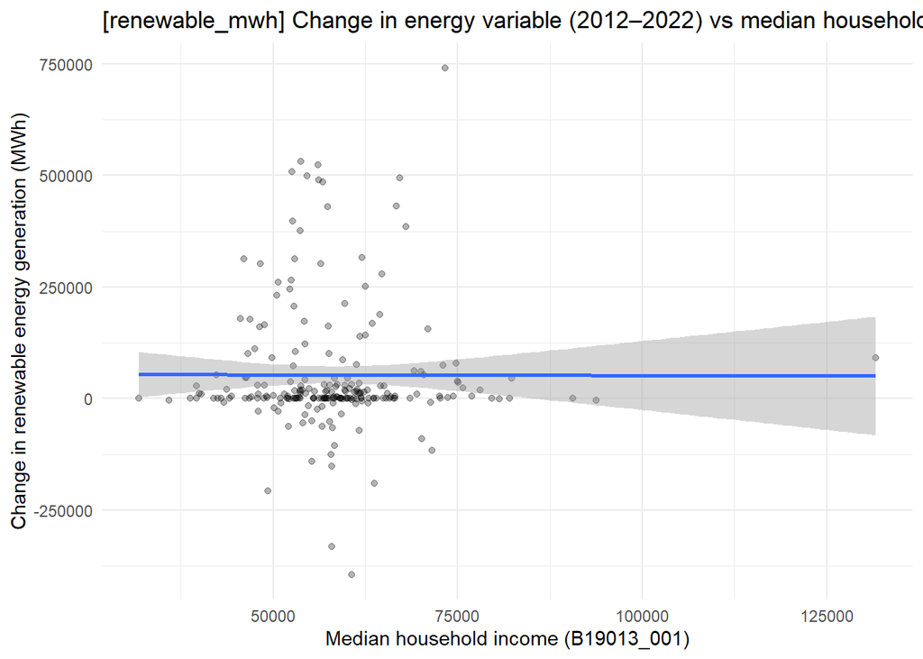

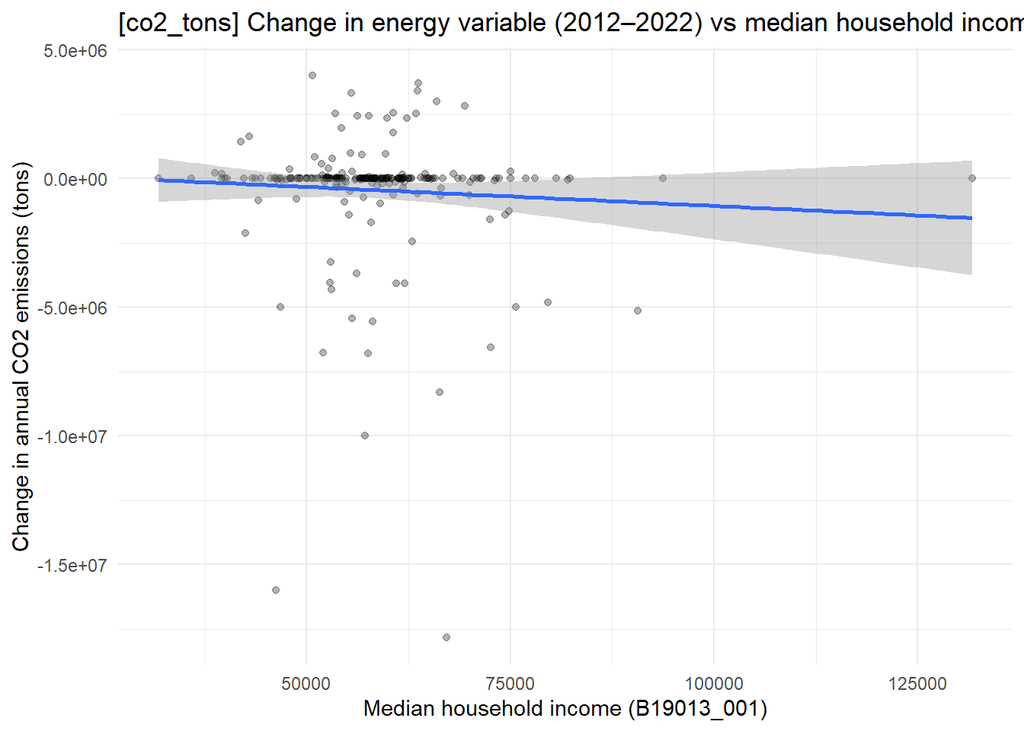

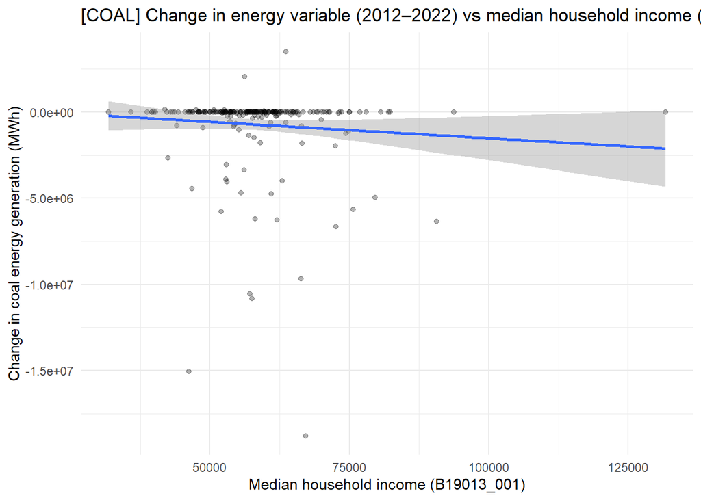

```r
walk(energy_vars, function(ev) {
  analysis_energy_change <- analysis_energy_change_by_var[[ev]]
  print(
    ggplot(analysis_energy_change, aes(x = median_income_aligned, y = energy_change)) +
      geom_point(alpha = 0.3) +
      geom_smooth(method = "lm", se = TRUE) +
      labs(
        title = paste0(
          "[",
          ev,
          "] Change in energy variable (",
          egrid_change_baseline_year,
          "–",
          analysis_year,
          ") vs median household income (",
          analysis_year,
          " ACS)"
        ),
        x = "Median household income (B19013_001)",
        y = energy_label_for(ev)
      ) +
      theme_minimal()
  )
})
```

## 6b. Change in energy variable vs change in median household income

For each energy variable, we correlate county-level `energy_change` with county-level `median_income_change` (analysis year minus baseline year income).

```r
analysis_income_change_by_var <- energy_vars |>
  set_names() |>
  map(function(ev) {
    analysis_county_energy_by_var[[ev]] |>
      drop_na(median_income_change, energy_change)
  })

walk(energy_vars, function(ev) {
  analysis_income_change <- analysis_income_change_by_var[[ev]]

  cat("\n============================\n")
  cat("INCOME-CHANGE CORRELATION [", ev, "]\n", sep = "")
  cat("============================\n")

  cor_income_change <- cor.test(
    analysis_income_change$median_income_change,
    analysis_income_change$energy_change,
    method = "pearson"
  )
  print(cor_income_change)
})
```

```
##
## ============================
## INCOME-CHANGE CORRELATION [renewable_mwh]
## ============================
##
##  Pearson's product-moment correlation
##
## data:  analysis_income_change$median_income_change and analysis_income_change$energy_change
## t = -0.31058, df = 218, p-value = 0.7564
## alternative hypothesis: true correlation is not equal to 0
## 95 percent confidence interval:
##  -0.1528770  0.1115509
## sample estimates:
##         cor
## -0.02103081
##
##
## ============================
## INCOME-CHANGE CORRELATION [co2_tons]
## ============================
##
##  Pearson's product-moment correlation
##
## data:  analysis_income_change$median_income_change and analysis_income_change$energy_change
## t = -0.29145, df = 218, p-value = 0.771
## alternative hypothesis: true correlation is not equal to 0
## 95 percent confidence interval:
##  -0.1516116  0.1128301
## sample estimates:
##        cor
## -0.0197359
##
##
## ============================
## INCOME-CHANGE CORRELATION [COAL]
## ============================
##
##  Pearson's product-moment correlation
##
## data:  analysis_income_change$median_income_change and analysis_income_change$energy_change
## t = -0.51992, df = 218, p-value = 0.6036
## alternative hypothesis: true correlation is not equal to 0
## 95 percent confidence interval:
##  -0.16668713  0.09753383
## sample estimates:
##        cor
## -0.0351916
```

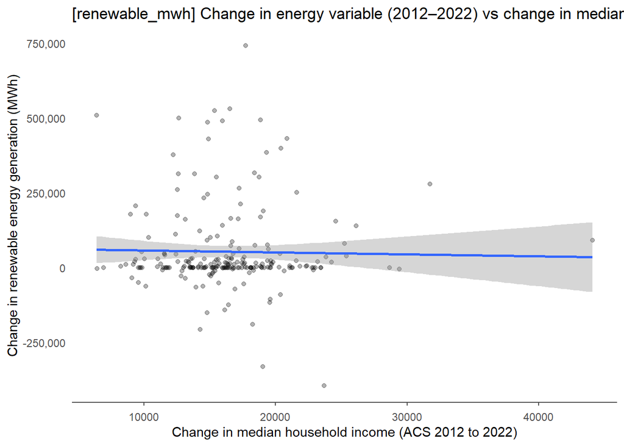

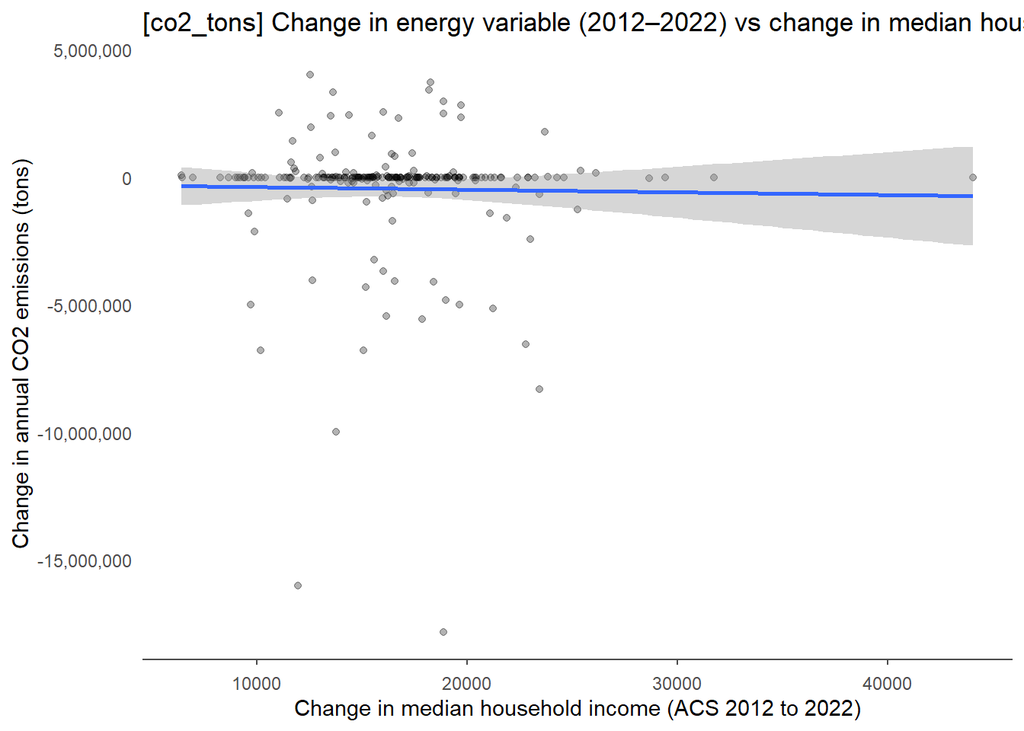

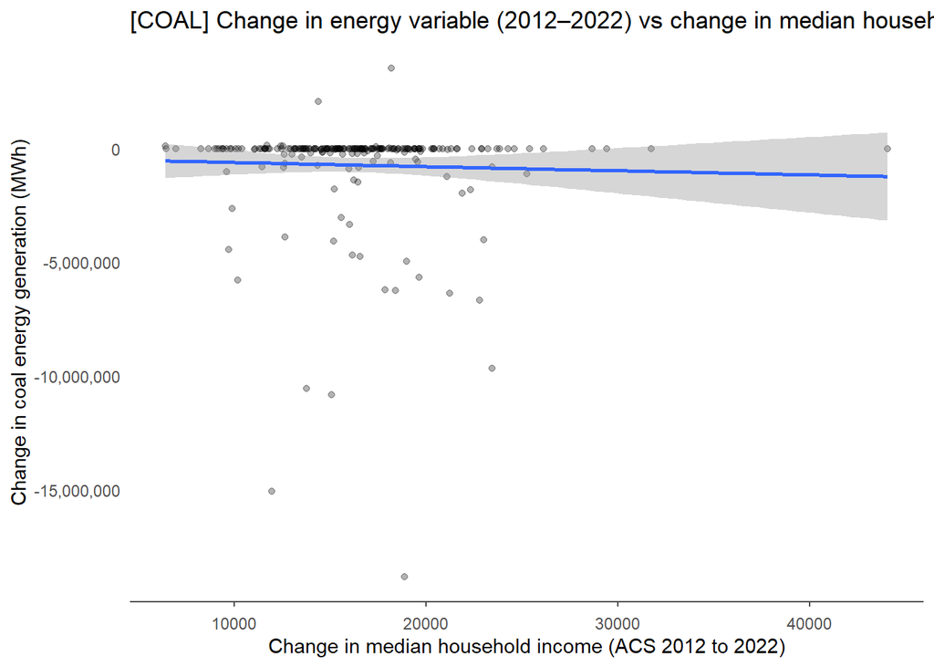

```r
walk(energy_vars, function(ev) {
  analysis_income_change <- analysis_income_change_by_var[[ev]]

  print(
    ggplot(analysis_income_change, aes(x = median_income_change, y = energy_change)) +
      geom_point(alpha = 0.3) +
      geom_smooth(method = "lm", se = TRUE) +
      scale_y_continuous(labels = scales::label_comma()) +
      labs(
        title = paste0(
          "[",
          ev,
          "] Change in energy variable (",
          egrid_change_baseline_year,
          "–",
          analysis_year,
          ") vs change in median household income"
        ),
        x = paste0(
          "Change in median household income (ACS ",
          egrid_change_baseline_year,
          " to ",
          analysis_year,
          ")"
        ),
        y = energy_label_for(ev)
      ) +
      theme_minimal() +
      theme(
        panel.grid.major = element_blank(),
        panel.grid.minor = element_blank(),
        axis.line.x = element_line(color = "grey30"),
        axis.ticks.x = element_line(color = "grey30")
      )
  )
})
```

## 7. Choropleth: change in selected energy variable

Fill is `energy_change` from `analysis_energy_change_by_var[[ev]]` for each `ev` in `energy_vars`. A light basemap of all counties in the selected states is drawn underneath for surrounding context.

```r
state_fips <- geography_df |>
  mutate(state_fips = str_sub(fips, 1, 2)) |>
  distinct(state_fips) |>
  pull(state_fips)

counties_sf <- counties(state = state_fips, cb = TRUE, year = 2020) |>
  st_transform(crs = 5070)

states_sf <- states(cb = TRUE, year = 2020) |>
  filter(STATEFP %in% state_fips) |>
  st_transform(crs = 5070)

counties_map_change_by_var <- analysis_energy_change_by_var |>
  map(~ counties_sf |>
    inner_join(
      .x |>
        select(fips, energy_change),
      by = c("GEOID" = "fips")
    ))

geography_outline <- counties_sf |>
  semi_join(geography_df, by = c("GEOID" = "fips")) |>
  st_union() |>
  st_as_sf()
```

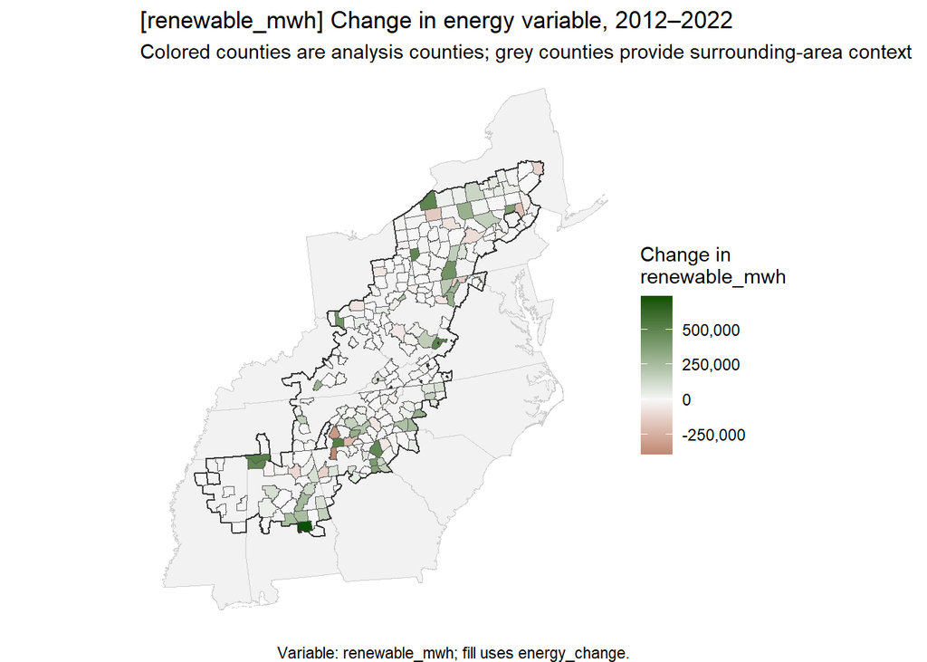

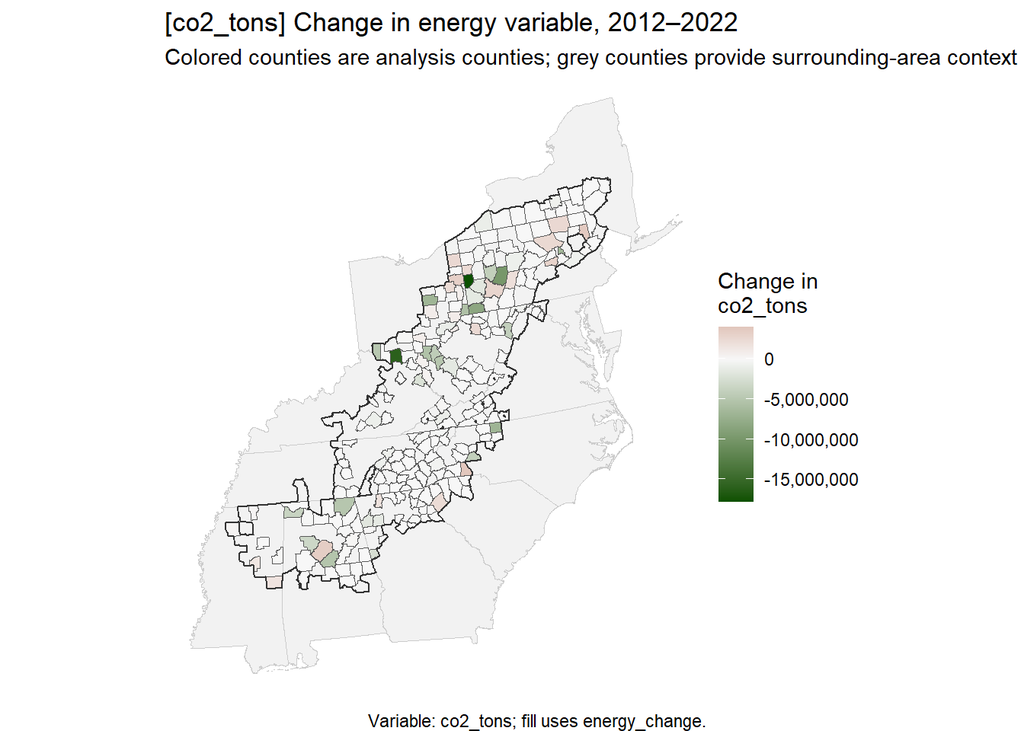

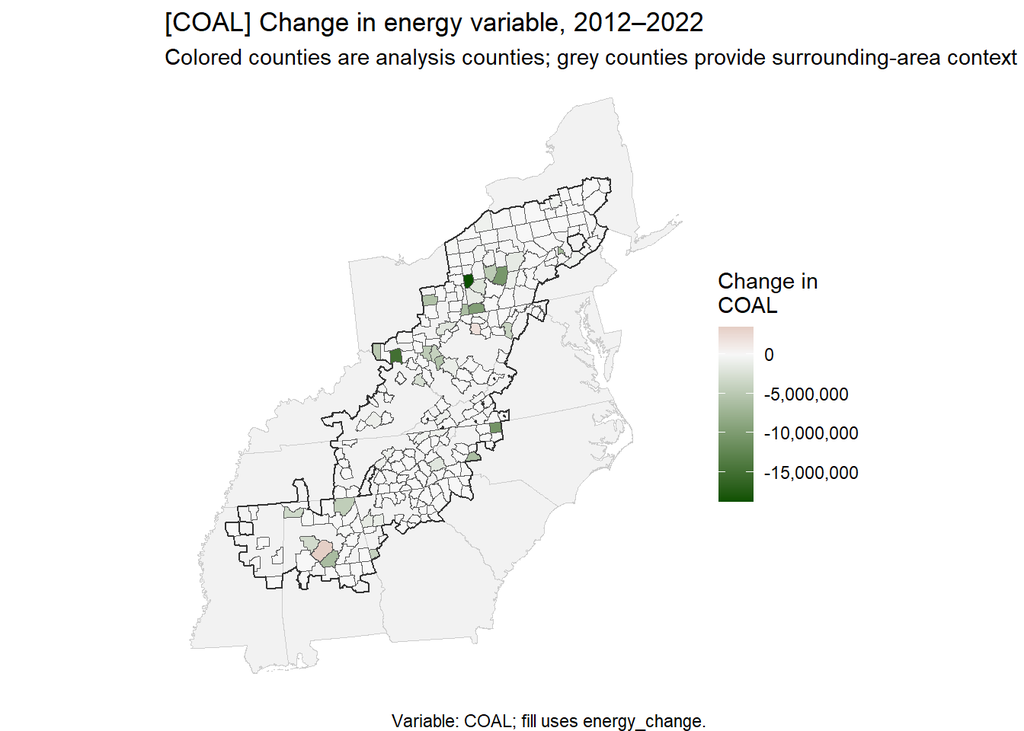

```r
walk(energy_vars, function(ev) {
  counties_map_change <- counties_map_change_by_var[[ev]]
  print(
    ggplot() +
      geom_sf(data = counties_sf, fill = "grey95", color = "grey95", linewidth = 0.05) +
      geom_sf(data = states_sf, fill = NA, color = "grey80", linewidth = 0.25) +
      geom_sf(data = counties_map_change, aes(fill = energy_change), color = "grey35", linewidth = 0.08) +
      geom_sf(data = geography_outline, fill = NA, color = "grey20", linewidth = 0.4) +
      scale_fill_gradient2(
        low = ifelse(ev == "renewable_mwh", "#7F2B0A", "#0C5000"),  # swapped for renewables
        mid = "#f7f7f7",
        high = ifelse(ev == "renewable_mwh", "#0C5000", "#7F2B0A"),  # swapped for renewables
        midpoint = 0,
        name = paste0("Change in \n", ev),
        labels = scales::label_comma()
      ) +
      theme_void() +
      theme(legend.position = "right") +
      labs(
        title = paste0(
          "[",
          ev,
          "] Change in energy variable, ",
          egrid_change_baseline_year,
          "–",
          analysis_year
        ),
        subtitle = "Colored counties are analysis counties; grey counties provide surrounding-area context",
        caption = paste0("Variable: ", ev, "; fill uses energy_change.")
      )
  )
})
```

## 8. Partisanship vs change in selected energy variable

```
##
## ============================
## PARTISANSHIP CORRELATION [renewable_mwh]
## ============================
##
##  Pearson's product-moment correlation
##
## data:  analysis_partisanship$PARTISAN_INDEX_REP and analysis_partisanship$energy_change
## t = 2.4592, df = 218, p-value = 0.01471
## alternative hypothesis: true correlation is not equal to 0
## 95 percent confidence interval:
##  0.03273174 0.29025572
## sample estimates:
##       cor
## 0.1642919
```

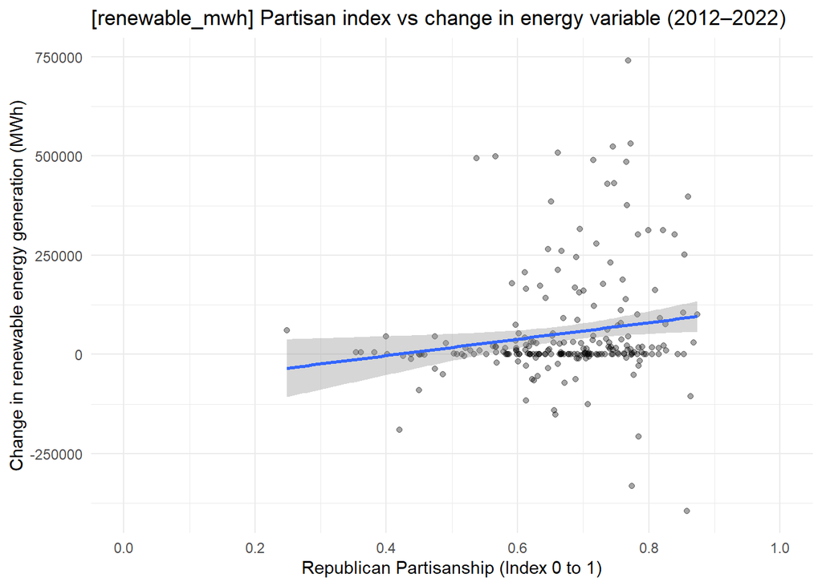

```
##
## ============================
## PARTISANSHIP CORRELATION [co2_tons]
## ============================
##
##  Pearson's product-moment correlation
##
## data:  analysis_partisanship$PARTISAN_INDEX_REP and analysis_partisanship$energy_change
## t = -0.80656, df = 218, p-value = 0.4208
## alternative hypothesis: true correlation is not equal to 0
## 95 percent confidence interval:
##  -0.18547895  0.07829056
## sample estimates:
##         cor
## -0.05454572
```

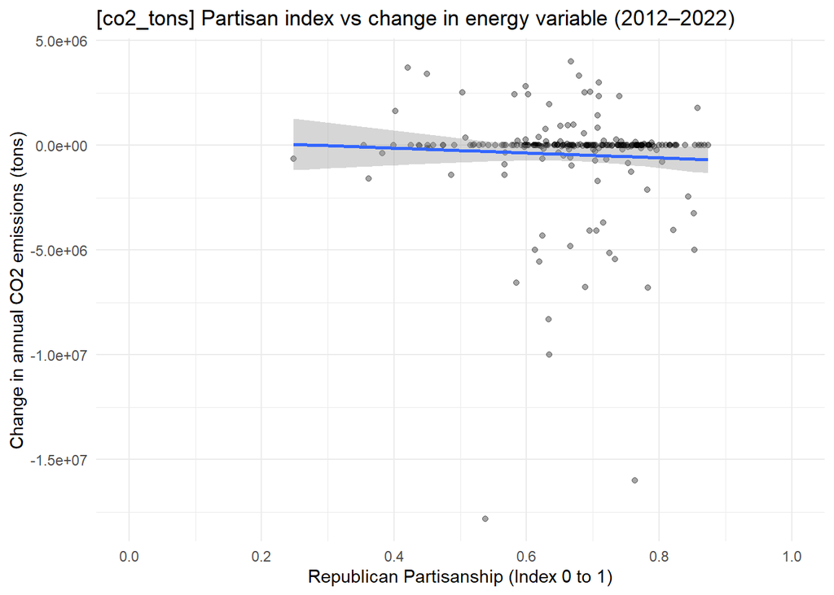

```
##
## ============================
## PARTISANSHIP CORRELATION [COAL]
## ============================
##
##  Pearson's product-moment correlation
##
## data:  analysis_partisanship$PARTISAN_INDEX_REP and analysis_partisanship$energy_change
## t = -0.42224, df = 218, p-value = 0.6733
## alternative hypothesis: true correlation is not equal to 0
## 95 percent confidence interval:
##  -0.1602516  0.1040788
## sample estimates:
##         cor
## -0.02858612
```

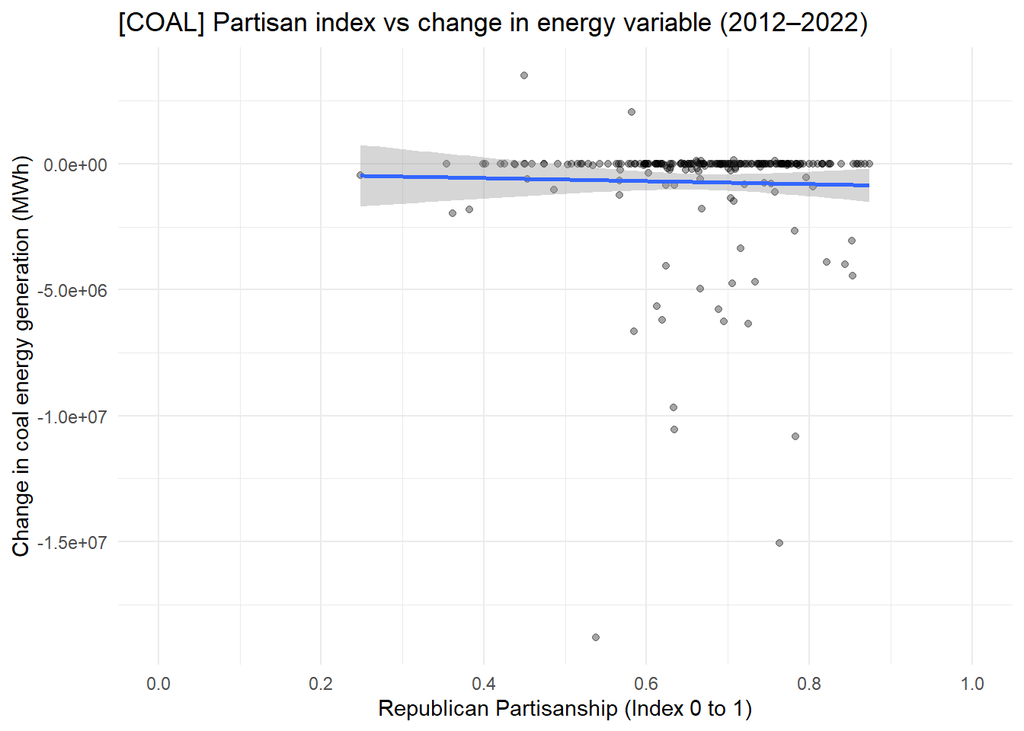

```r
# Read partisanship directly from CSV and keep 2022 county-level values.
partisan_join <- read_csv("partisanship.csv", show_col_types = FALSE) |>
  filter(YEAR == 2022) |>
  transmute(
    fips = str_pad(as.character(STCOFIPS10), 5, pad = "0"),
    PARTISAN_INDEX_REP = as.numeric(PARTISAN_INDEX_REP)
  )

if (nrow(partisan_join) == 0) {
  stop("No 2022 rows found in partisanship.csv.")
}

walk(energy_vars, function(ev) {
  analysis_energy_change <- analysis_energy_change_by_var[[ev]]
  analysis_partisanship <- analysis_energy_change |>
    left_join(partisan_join, by = "fips") |>
    drop_na(PARTISAN_INDEX_REP, energy_change)

  cor_partisan <- cor.test(
    analysis_partisanship$PARTISAN_INDEX_REP,
    analysis_partisanship$energy_change,
    method = "pearson"
  )

  cat("\n============================\n")
  cat("PARTISANSHIP CORRELATION [", ev, "]\n", sep = "")
  cat("============================\n")
  print(cor_partisan)

  print(
    ggplot(
      analysis_partisanship,
      aes(x = PARTISAN_INDEX_REP, y = energy_change)
    ) +
      geom_point(alpha = 0.35) +
      geom_smooth(method = "lm", se = TRUE) +
      scale_x_continuous(
        limits = c(0, 1),
        breaks = seq(0, 1, by = 0.2),
        labels = scales::label_number(accuracy = 0.1)
      ) +
      labs(
        title = paste0(
          "[",
          ev,
          "] Partisan index vs change in energy variable (",
          egrid_change_baseline_year,
          "–",
          analysis_year,
          ")"
        ),
        x = "Republican Partisanship (Index 0 to 1)",
        y = energy_label_for(ev)
      ) +
      theme_minimal()
  )
})
```

## 9. Metro vs micro vs rural (Census CBSA delineations)

```r
# CBSA polygons from ACS (loaded once in section 3, cached in census_cache)

# Classify counties by whether their interior point lies in a metro/micro CBSA polygon
county_cbsa <- counties_sf |>
  st_point_on_surface() |>
  st_join(cbsa_sf, join = st_within, left = TRUE) |>
  st_drop_geometry() |>
  transmute(
    fips = GEOID,
    cbsa_type = replace_na(cbsa_type, "Rural")
  )
```

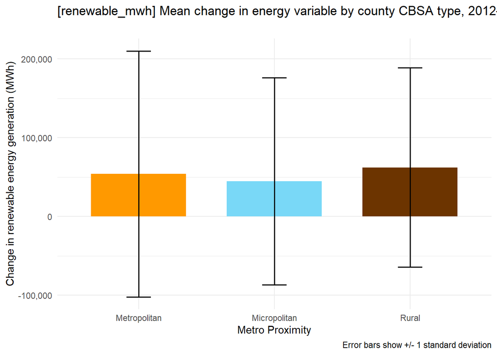

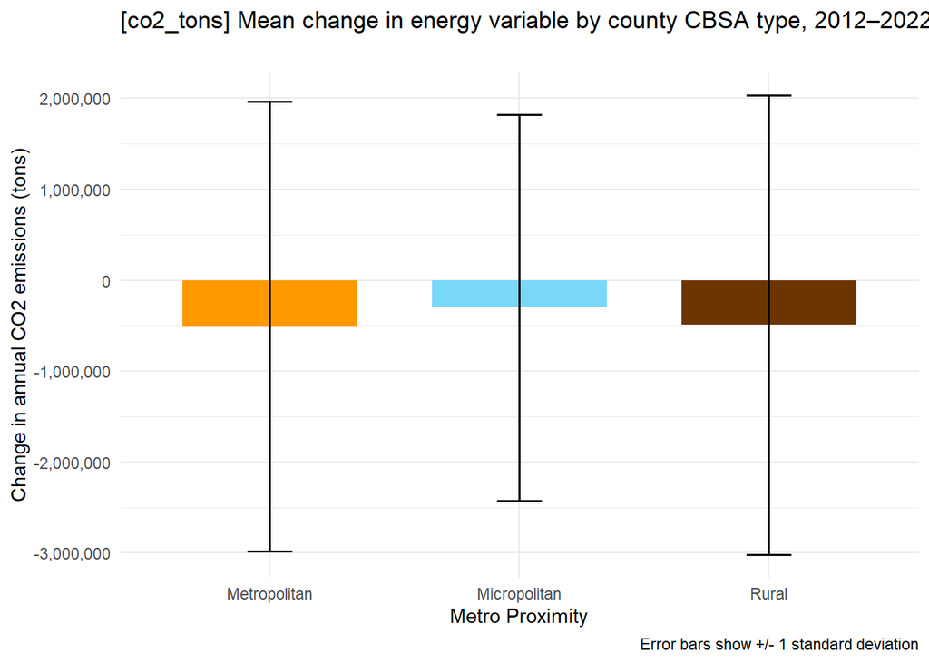

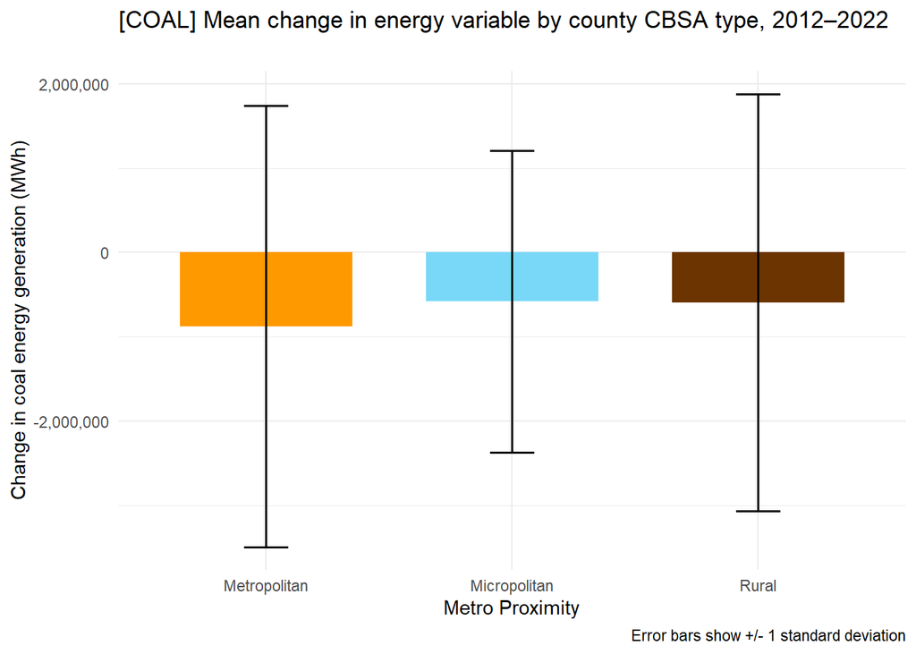

```r
walk(energy_vars, function(ev) {
  analysis_energy_change <- analysis_energy_change_by_var[[ev]]
  analysis_cbsa <- analysis_energy_change |>
    left_join(county_cbsa, by = "fips") |>
    mutate(
      county_type = cbsa_type,
      county_type = factor(county_type, levels = c("Metropolitan", "Micropolitan", "Rural"))
    )

  cbsa_summary <- analysis_cbsa |>
    group_by(county_type) |>
    summarise(
      n = n(),
      mean_change = mean(energy_change, na.rm = TRUE),
      sd_change = sd(energy_change, na.rm = TRUE),
      .groups = "drop"
    )

  print(
    ggplot(cbsa_summary, aes(x = county_type, y = mean_change, fill = county_type)) +
      geom_col(width = 0.7, show.legend = FALSE) +
      geom_errorbar(
        aes(ymin = mean_change - sd_change, ymax = mean_change + sd_change),
        width = 0.18,
        linewidth = 0.6
      ) +
      scale_y_continuous(labels = scales::label_comma()) +
      scale_fill_manual(values = c("Metropolitan" = "#ff9900", "Micropolitan" = "#79d8f7", "Rural" = "#6C3400")) +
      labs(
        title = paste0(
          "[",
          ev,
          "] Mean change in energy variable by county CBSA type, ",
          egrid_change_baseline_year,
          "–",
          analysis_year
        ),
        subtitle = "",
        x = "Metro Proximity",
        y = energy_label_for(ev),
        caption = "Error bars show +/- 1 standard deviation"
      ) +
      theme_minimal()
  )
})
```

## 10. Linear model on asinh-transformed `energy_change`

```
##
## ============================
## LINEAR MODEL [renewable_mwh]: asinh(energy_change)
## ============================
## Model: asinh(energy_change) ~ z_median_income_aligned + z_median_income_change + z_partisan_index_rep + state + cbsa_factor + hasplan_score
## Rows used: 220
##
## Call:
## lm(formula = lm_formula, data = model_df)
##
## Residuals:
##     Min      1Q  Median      3Q     Max
## -21.768  -3.788   2.085   6.055  12.976
##
## Coefficients:
##                         Estimate Std. Error t value Pr(>|t|)
## (Intercept)               6.2461     2.0778   3.006  0.00299 **
## z_median_income_aligned   1.4581     1.1519   1.266  0.20705
## z_median_income_change   -0.9501     1.0711  -0.887  0.37616
## z_partisan_index_rep      1.1716     0.7523   1.558  0.12093
## stateGeorgia              0.8555     2.8501   0.300  0.76437
## stateKentucky             1.2230     3.4146   0.358  0.72059
## stateMaryland            -1.8657     5.3738  -0.347  0.72882
## stateMississippi         -0.6181     4.4053  -0.140  0.88856
## stateNew York             3.9818     3.2525   1.224  0.22230
## stateNorth Carolina       0.5755     2.5971   0.222  0.82485
## stateOhio                -5.4792     2.5759  -2.127  0.03463 *
## statePennsylvania        -3.3668     2.4324  -1.384  0.16785
## stateSouth Carolina      -1.3168     3.6962  -0.356  0.72203
## stateTennessee           -0.4884     2.6131  -0.187  0.85193
## stateVirginia            -2.3161     3.0245  -0.766  0.44470
## stateWest Virginia       -2.7639     2.6951  -1.026  0.30635
## cbsa_factorMicropolitan   0.5439     1.5318   0.355  0.72289
## cbsa_factorRural          1.6553     1.7963   0.922  0.35788
## hasplan_score1           -1.1334     1.5152  -0.748  0.45536
## hasplan_score2           -1.3794     1.5100  -0.914  0.36206
## ---
## Signif. codes:  0 '***' 0.001 '**' 0.01 '*' 0.05 '.' 0.1 ' ' 1
##
## Residual standard error: 8.531 on 200 degrees of freedom
```

[output cut: 13 more lines]

```
## # ℹ 2 more variables: energy_change_lower <dbl>, energy_change_upper <dbl>
##
## ============================
## EMMEANS (BACK-TRANSFORMED): partisan_index_rep grid [renewable_mwh]
## ============================
## # A tibble: 5 × 10
##   partisan_index_rep energy_change_est energy_change_lower energy_change_upper
##                <dbl>             <dbl>               <dbl>               <dbl>
## 1               0               -2.82           -24646.                   731.
## 2               0.25             0.964             -70.5                  391.
## 3               0.5             16.1                 0.802                248.
## 4               0.75           220.                 36.7                 1315.
## 5               1             3005.                 31.3               288424.
## # ℹ 6 more variables: z_partisan_index_rep <dbl>, emmean <dbl>, SE <dbl>,
## #   df <dbl>, lower.CL <dbl>, upper.CL <dbl>
```

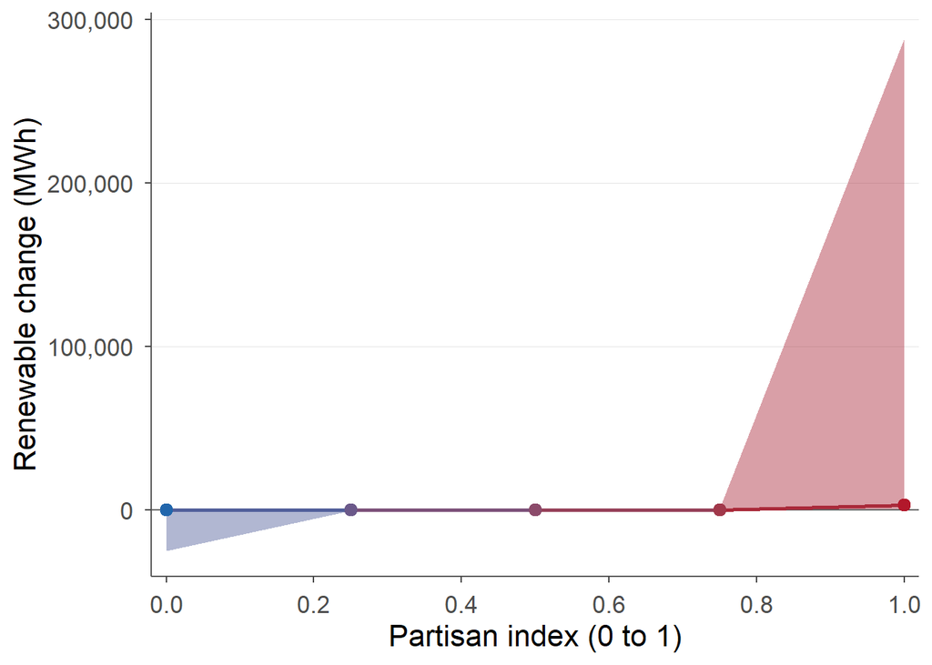

```
##
## ============================
## ANOVA on Linear Model
## ============================
## Analysis of Variance Table
##
## Response: asinh_energy_change
##                          Df  Sum Sq Mean Sq F value  Pr(>F)
## z_median_income_aligned   1     9.0    9.04  0.1242 0.72487
## z_median_income_change    1     2.4    2.35  0.0323 0.85757
## z_partisan_index_rep      1   427.8  427.80  5.8780 0.01622 *
## state                    12  1261.9  105.16  1.4449 0.14817
## cbsa_factor               2    73.7   36.83  0.5061 0.60360
## hasplan_score             2    66.7   33.35  0.4582 0.63310
## Residuals               200 14556.0   72.78
## ---
## Signif. codes:  0 '***' 0.001 '**' 0.01 '*' 0.05 '.' 0.1 ' ' 1
##
## ============================
## Drop1 Test (LRT)
## ============================
## Single term deletions
##
## Model:
## asinh_energy_change ~ z_median_income_aligned + z_median_income_change +
##     z_partisan_index_rep + state + cbsa_factor + hasplan_score
##                         Df Sum of Sq   RSS    AIC Pr(>Chi)
## <none>                               14556 962.27
## z_median_income_aligned  1    116.61 14673 962.02   0.1852
## z_median_income_change   1     57.26 14613 961.13   0.3527
## z_partisan_index_rep     1    176.55 14732 962.92   0.1034
## state                   12   1254.39 15810 956.45   0.1102
## cbsa_factor              2     62.72 14619 959.21   0.6232
## hasplan_score            2     66.69 14623 959.27   0.6048
##
## ============================
## TUKEY POST-HOC: cbsa_factor [renewable_mwh]
## ============================
```

```
##   Tukey multiple comparisons of means
##     95% family-wise confidence level
##
## Fit: aov(formula = lm_formula, data = model_df)
##
## $cbsa_factor
##                                diff       lwr      upr     p adj
## Micropolitan-Metropolitan 0.3229432 -2.889384 3.535270 0.9694172
## Rural-Metropolitan        1.1684526 -2.221715 4.558620 0.6948957
## Rural-Micropolitan        0.8455094 -2.876778 4.567797 0.8535195
##
##
## Significant cbsa_factor pair differences (Tukey-adjusted p < 0.05):
## None at p < 0.05.
##
## ============================
## F-TEST: cbsa_factor [renewable_mwh]
## ============================
## Model comparison (reduced vs full with cbsa_factor):
## Analysis of Variance Table
##
## Model 1: asinh_energy_change ~ z_median_income_aligned + z_median_income_change +
##     z_partisan_index_rep + state + hasplan_score
## Model 2: asinh_energy_change ~ z_median_income_aligned + z_median_income_change +
##     z_partisan_index_rep + state + cbsa_factor + hasplan_score
##   Res.Df   RSS Df Sum of Sq      F Pr(>F)
## 1    202 14619
## 2    200 14556  2    62.721 0.4309 0.6505
##
## ---
##
## ============================
## LINEAR MODEL [co2_tons]: asinh(energy_change)
## ============================
## Model: asinh(energy_change) ~ z_median_income_aligned + z_median_income_change + z_partisan_index_rep + state + cbsa_factor + hasplan_score
## Rows used: 220
##
## Call:
## lm(formula = lm_formula, data = model_df)
##
```

[output cut: 81 more lines]

```
## Model:
## asinh_energy_change ~ z_median_income_aligned + z_median_income_change +
##     z_partisan_index_rep + state + cbsa_factor + hasplan_score
##                         Df Sum of Sq   RSS    AIC Pr(>Chi)
## <none>                               19608 1027.8
## z_median_income_aligned  1     55.32 19663 1026.4   0.4311
## z_median_income_change   1      5.53 19613 1025.9   0.8032
## z_partisan_index_rep     1     67.52 19675 1026.6   0.3845
## state                   12   1279.83 20888 1017.7   0.3065
## cbsa_factor              2    235.25 19843 1026.4   0.2693
## hasplan_score            2     69.80 19678 1024.6   0.6765
##
## ============================
## TUKEY POST-HOC: cbsa_factor [co2_tons]
## ============================
```

```
##   Tukey multiple comparisons of means
##     95% family-wise confidence level
##
## Fit: aov(formula = lm_formula, data = model_df)
##
## $cbsa_factor
##                                diff       lwr      upr     p adj
## Micropolitan-Metropolitan -1.211322 -4.939638 2.516993 0.7235642
## Rural-Metropolitan         1.461036 -2.473685 5.395757 0.6555605
## Rural-Micropolitan         2.672358 -1.647831 6.992548 0.3121464
##
##
## Significant cbsa_factor pair differences (Tukey-adjusted p < 0.05):
## None at p < 0.05.
##
## ============================
## F-TEST: cbsa_factor [co2_tons]
## ============================
## Model comparison (reduced vs full with cbsa_factor):
## Analysis of Variance Table
##
## Model 1: asinh_energy_change ~ z_median_income_aligned + z_median_income_change +
##     z_partisan_index_rep + state + hasplan_score
## Model 2: asinh_energy_change ~ z_median_income_aligned + z_median_income_change +
##     z_partisan_index_rep + state + cbsa_factor + hasplan_score
##   Res.Df   RSS Df Sum of Sq      F Pr(>F)
## 1    202 19843
## 2    200 19608  2    235.25 1.1998 0.3034
##
## ---
##
## ============================
## LINEAR MODEL [COAL]: asinh(energy_change)
## ============================
## Model: asinh(energy_change) ~ z_median_income_aligned + z_median_income_change + z_partisan_index_rep + state + cbsa_factor + hasplan_score
## Rows used: 220
##
## Call:
## lm(formula = lm_formula, data = model_df)
##
```

[output cut: 43 more lines]

```
## # ℹ 2 more variables: energy_change_lower <dbl>, energy_change_upper <dbl>
##
## ============================
## EMMEANS (BACK-TRANSFORMED): partisan_index_rep grid [COAL]
## ============================
## # A tibble: 5 × 10
##   partisan_index_rep energy_change_est energy_change_lower energy_change_upper
##                <dbl>             <dbl>               <dbl>               <dbl>
## 1               0               -0.525             -1530.              559.
## 2               0.25            -2.01               -265.               14.7
## 3               0.5             -5.40                -53.1              -0.113
## 4               0.75           -14.0                 -61.9              -3.08
## 5               1              -35.9               -1598.               -0.497
## # ℹ 6 more variables: z_partisan_index_rep <dbl>, emmean <dbl>, SE <dbl>,
## #   df <dbl>, lower.CL <dbl>, upper.CL <dbl>
```

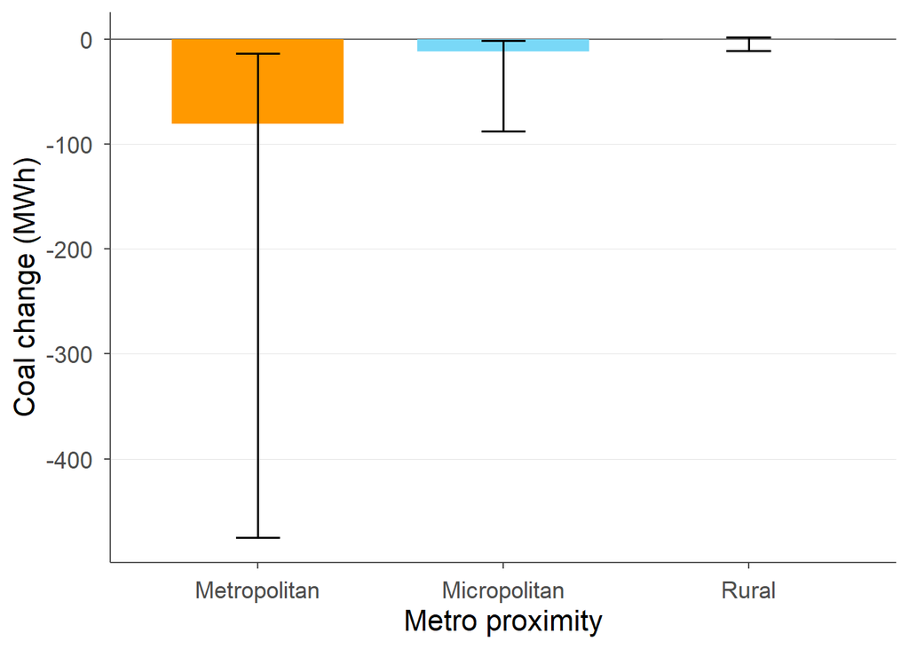

```
##
## ============================
## ANOVA on Linear Model
## ============================
## Analysis of Variance Table
##
## Response: asinh_energy_change
##                          Df  Sum Sq Mean Sq F value  Pr(>F)
## z_median_income_aligned   1   198.3 198.307  3.9401 0.04852 *
## z_median_income_change    1    32.8  32.771  0.6511 0.42067
## z_partisan_index_rep      1     0.1   0.104  0.0021 0.96379
## state                    12   887.4  73.947  1.4692 0.13818
## cbsa_factor               2   425.6 212.814  4.2283 0.01590 *
## hasplan_score             2     6.5   3.262  0.0648 0.93726
## Residuals               200 10066.1  50.331
## ---
## Signif. codes:  0 '***' 0.001 '**' 0.01 '*' 0.05 '.' 0.1 ' ' 1
##
## ============================
## Drop1 Test (LRT)
## ============================
## Single term deletions
##
## Model:
## asinh_energy_change ~ z_median_income_aligned + z_median_income_change +
##     z_partisan_index_rep + state + cbsa_factor + hasplan_score
##                         Df Sum of Sq   RSS    AIC Pr(>Chi)
## <none>                               10066 881.13
## z_median_income_aligned  1      0.59 10067 879.14  0.90986
## z_median_income_change   1      3.97 10070 879.21  0.76848
## z_partisan_index_rep     1     22.95 10089 879.63  0.47906
## state                   12    850.07 10916 874.96  0.12077
## cbsa_factor              2    406.20 10472 885.83  0.01289 *
## hasplan_score            2      6.52 10073 877.27  0.93121
## ---
## Signif. codes:  0 '***' 0.001 '**' 0.01 '*' 0.05 '.' 0.1 ' ' 1
##
## ============================
## TUKEY POST-HOC: cbsa_factor [COAL]
## ============================
```

```
##   Tukey multiple comparisons of means
##     95% family-wise confidence level
##
## Fit: aov(formula = lm_formula, data = model_df)
##
## $cbsa_factor
##                               diff         lwr      upr     p adj
## Micropolitan-Metropolitan 1.093410 -1.57793888 3.764759 0.5988855
## Rural-Metropolitan        2.781793 -0.03744642 5.601033 0.0540113
## Rural-Micropolitan        1.688383 -1.40704565 4.783812 0.4036168
##
##
## Significant cbsa_factor pair differences (Tukey-adjusted p < 0.05):
## None at p < 0.05.
##
## ============================
## F-TEST: cbsa_factor [COAL]
## ============================
## Model comparison (reduced vs full with cbsa_factor):
## Analysis of Variance Table
##
## Model 1: asinh_energy_change ~ z_median_income_aligned + z_median_income_change +
##     z_partisan_index_rep + state + hasplan_score
## Model 2: asinh_energy_change ~ z_median_income_aligned + z_median_income_change +
##     z_partisan_index_rep + state + cbsa_factor + hasplan_score
##   Res.Df   RSS Df Sum of Sq      F  Pr(>F)
## 1    202 10472
## 2    200 10066  2     406.2 4.0353 0.01914 *
## ---
## Signif. codes:  0 '***' 0.001 '**' 0.01 '*' 0.05 '.' 0.1 ' ' 1
##
## ---
```

```r
# Ensure partisanship join exists even if section 8 has not run yet.
if (!exists("partisan_join")) {
  partisan_join <- read_csv("partisanship.csv", show_col_types = FALSE) |>
    filter(YEAR == 2022) |>
    transmute(
      fips = str_pad(as.character(STCOFIPS10), 5, pad = "0"),
      partisan_index_rep = as.numeric(PARTISAN_INDEX_REP)
    )
}

partisan_join_glmm <- partisan_join |>
  transmute(
    fips,
    partisan_index_rep = if ("partisan_index_rep" %in% names(partisan_join)) {
      as.numeric(partisan_index_rep)
    } else {
      as.numeric(PARTISAN_INDEX_REP)
    }
  )

# Load hasplan data
hasplan_df <- read_csv("hasplan.csv", show_col_types = FALSE) |>
  clean_names() |>
  transmute(
    fips = str_pad(fips, 5, pad = "0"),
    hasplan_score = factor(score)  # 3 possible states as factor
  )

walk(energy_vars, function(ev) {
  model_df <- analysis_county_energy_by_var[[ev]] |>
    left_join(
      geography_df |>
        select(fips, state),
      by = "fips"
    ) |>
    left_join(
      county_cbsa |>
        transmute(
          fips,
          cbsa_factor = case_when(
            cbsa_type == "Metropolitan" ~ "Metropolitan",
            cbsa_type == "Micropolitan" ~ "Micropolitan",
            TRUE ~ "Rural"
          )
        ),
      by = "fips"
    ) |>
    left_join(partisan_join_glmm, by = "fips") |>
    left_join(hasplan_df, by = "fips") |>
    mutate(
      asinh_energy_change = asinh(energy_change),
      state = factor(state),
      cbsa_factor = factor(cbsa_factor, levels = c("Metropolitan", "Micropolitan", "Rural"))
    ) |>
    drop_na(
      asinh_energy_change,
      median_income_aligned,
      median_income_change,
      partisan_index_rep,
      state,
      cbsa_factor,
      hasplan_score
    )

  # Check for counties missing from hasplan dataset
  all_counties <- analysis_county_energy_by_var[[ev]] |> pull(fips) |> unique()
  hasplan_counties <- hasplan_df |> pull(fips) |> unique()
  missing_counties <- setdiff(all_counties, hasplan_counties)

  if (length(missing_counties) > 0) {
    cat("\n⚠️ WARNING [", ev, "]: ", length(missing_counties),
        " counties present in other variables are MISSING from hasplan dataset:\n", sep = "")
    cat(paste(head(missing_counties, 20), collapse = ", "))
    if (length(missing_counties) > 20) {
      cat("... and", length(missing_counties) - 20, "more")
    }
    cat("\n")
  }

  model_df <- model_df |>
    mutate(
      z_median_income_aligned = as.numeric(scale(median_income_aligned)),
      z_median_income_change = as.numeric(scale(median_income_change)),
      z_partisan_index_rep = as.numeric(scale(partisan_index_rep))
    ) |>
    drop_na(
      z_median_income_aligned,
      z_median_income_change,
      z_partisan_index_rep
    )

  # Linear model with all fixed effects (no random effects)
  lm_formula <- asinh_energy_change ~
    z_median_income_aligned +
    z_median_income_change +
    z_partisan_index_rep +
    state +
    cbsa_factor +
    hasplan_score

  lm_fit <- lm(lm_formula, data = model_df)

  partisan_mean <- mean(model_df$partisan_index_rep, na.rm = TRUE)
  partisan_sd <- sd(model_df$partisan_index_rep, na.rm = TRUE)

  partisanship_grid <- c(0, 0.25, 0.5, 0.75, 1)
  partisanship_at <- (partisanship_grid - partisan_mean) / partisan_sd

  cat("\n============================\n")
  cat("LINEAR MODEL [", ev, "]: asinh(energy_change)\n", sep = "")
  cat("============================\n")
  cat(
    "Model: asinh(energy_change) ~ z_median_income_aligned + z_median_income_change + z_partisan_index_rep + state + cbsa_factor + hasplan_score\n"
  )
  cat("Rows used:", nrow(model_df), "\n")
  print(summary(lm_fit))

  cat("\n============================\n")
  cat("EMMEANS (BACK-TRANSFORMED): cbsa_factor [", ev, "]\n", sep = "")
  cat("============================\n")
  emm_cbsa <- emmeans(lm_fit, ~ cbsa_factor)
  emm_cbsa_bt <- summary(emm_cbsa) |>
    as_tibble() |>
    mutate(
      energy_change_est = sinh(emmean),
      energy_change_lower = sinh(lower.CL),
      energy_change_upper = sinh(upper.CL)
    )
  print(emm_cbsa_bt)

  cat("\n============================\n")
  cat("EMMEANS (BACK-TRANSFORMED): partisan_index_rep grid [", ev, "]\n", sep = "")
  cat("============================\n")
  emm_partisan <- emmeans(
    lm_fit,
    ~ z_partisan_index_rep,
    at = list(z_partisan_index_rep = partisanship_at)
  )
  emm_partisan_bt <- summary(emm_partisan) |>
    as_tibble() |>
    mutate(
      partisan_index_rep = partisanship_grid,
      energy_change_est = sinh(emmean),
      energy_change_lower = sinh(lower.CL),
      energy_change_upper = sinh(upper.CL)
    ) |>
    select(
      partisan_index_rep,
      energy_change_est,
      energy_change_lower,
      energy_change_upper,
      everything()
    )
  print(emm_partisan_bt)

  emmeans_plot_theme <- theme_minimal(base_size = 14) +
    theme(
      panel.grid.major.x = element_blank(),
      panel.grid.major.y = element_line(color = "grey90", linewidth = 0.35),
      panel.grid.minor = element_blank(),
      axis.title = element_text(size = 16, face = "plain"),
      axis.text = element_text(size = 13),
      axis.line.x = element_line(color = "grey35", linewidth = 0.4),
      axis.line.y = element_line(color = "grey35", linewidth = 0.4),
      axis.ticks = element_line(color = "grey28", linewidth = 0.4)
    )

  if (ev == "renewable_mwh") {
    grad_low <- "#2166AC"
    grad_high <- "#B2182B"

    partisan_line_seg <- emm_partisan_bt |>
      mutate(
        xend = lead(partisan_index_rep),
        yend = lead(energy_change_est)
      ) |>
      filter(!is.na(xend)) |>
      mutate(x_mid = (partisan_index_rep + xend) / 2)

    seg_ids <- seq_len(nrow(emm_partisan_bt) - 1)
    partisan_ribbon_poly <- map_dfr(seg_ids, function(i) {
      tibble(
        x = c(
          emm_partisan_bt$partisan_index_rep[i],
          emm_partisan_bt$partisan_index_rep[i + 1],
          emm_partisan_bt$partisan_index_rep[i + 1],
          emm_partisan_bt$partisan_index_rep[i]
        ),
        y = c(
          emm_partisan_bt$energy_change_lower[i],
          emm_partisan_bt$energy_change_lower[i + 1],
          emm_partisan_bt$energy_change_upper[i + 1],
          emm_partisan_bt$energy_change_upper[i]
        ),
        seg_id = i,
        x_mid = mean(c(
          emm_partisan_bt$partisan_index_rep[i],
          emm_partisan_bt$partisan_index_rep[i + 1]
        ))
      )
    })

    print(
      ggplot() +
        geom_polygon(
          data = partisan_ribbon_poly,
          aes(x = x, y = y, group = seg_id, fill = x_mid),
          alpha = 0.45,
          color = NA
        ) +
        scale_fill_gradient(low = grad_low, high = grad_high, limits = c(0, 1), guide = "none") +
        geom_hline(yintercept = 0, color = "grey40", linewidth = 0.45) +
        geom_segment(
          data = partisan_line_seg,
          aes(
            x = partisan_index_rep,
            xend = xend,
            y = energy_change_est,
            yend = yend,
            color = x_mid
          ),
          linewidth = 1,
          lineend = "round"
        ) +
        geom_point(
          data = emm_partisan_bt,
          aes(x = partisan_index_rep, y = energy_change_est, color = partisan_index_rep),
          size = 2.8
        ) +
        scale_color_gradient(low = grad_low, high = grad_high, limits = c(0, 1), guide = "none") +
        scale_x_continuous(
          limits = c(0, 1),
          breaks = seq(0, 1, by = 0.2),
          labels = scales::label_number(accuracy = 0.1),
          expand = expansion(mult = c(0.02, 0.02))
        ) +
        scale_y_continuous(labels = scales::label_comma()) +
        labs(
          x = "Partisan index (0 to 1)",
          y = "Renewable change (MWh)"
        ) +
        emmeans_plot_theme
    )
  }

  if (ev == "COAL") {
    print(
      ggplot(
        emm_cbsa_bt,
        aes(x = cbsa_factor, y = energy_change_est, fill = cbsa_factor)
      ) +
        geom_hline(yintercept = 0, color = "grey40", linewidth = 0.45) +
        geom_col(width = 0.7, show.legend = FALSE) +
        geom_errorbar(
          aes(ymin = energy_change_lower, ymax = energy_change_upper),
          width = 0.18,
          linewidth = 0.65
        ) +
        scale_y_continuous(labels = scales::label_comma()) +
        scale_fill_manual(
          values = c(
            "Metropolitan" = "#ff9900",
            "Micropolitan" = "#79d8f7",
            "Rural/Neither" = "#6C3400"
          )
        ) +
        labs(
          x = "Metro proximity",
          y = "Coal change (MWh)"
        ) +
        emmeans_plot_theme
    )
  }

  # ANOVA on the model
  cat("\n============================\n")
  cat("ANOVA on Linear Model\n")
  cat("============================\n")
  print(anova(lm_fit))

  # Drop1 test
  cat("\n============================\n")
  cat("Drop1 Test (LRT)\n")
  cat("============================\n")
  print(drop1(lm_fit, test = "Chisq"))

  # Post-hoc Tukey pairwise tests for cbsa_factor
  cat("\n============================\n")
  cat("TUKEY POST-HOC: cbsa_factor [", ev, "]\n", sep = "")
  cat("============================\n")

  aov_fit <- aov(lm_formula, data = model_df)
  tukey_cbsa <- TukeyHSD(aov_fit, which = "cbsa_factor")
  print(tukey_cbsa)

  # Convert to tibble and show significant results
  tukey_cbsa_tbl <- as.data.frame(tukey_cbsa$cbsa_factor) |>
    rownames_to_column("comparison") |>
    as_tibble() |>
    rename(
      diff = diff,
      conf_low = lwr,
      conf_high = upr,
      p_adj = `p adj`
    ) |>
    arrange(p_adj)

  sig_tukey_cbsa <- tukey_cbsa_tbl |>
    filter(p_adj < 0.05)

  cat("\nSignificant cbsa_factor pair differences (Tukey-adjusted p < 0.05):\n")
  if (nrow(sig_tukey_cbsa) == 0) {
    cat("None at p < 0.05.\n")
  } else {
    print(sig_tukey_cbsa)
  }

  # F-test specifically for cbsa_factor
  cat("\n============================\n")
  cat("F-TEST: cbsa_factor [", ev, "]\n", sep = "")
  cat("============================\n")

  # Reduced model without cbsa_factor
  lm_formula_reduced <- asinh_energy_change ~
    z_median_income_aligned +
    z_median_income_change +
    z_partisan_index_rep +
    state +
    hasplan_score

  lm_fit_reduced <- lm(lm_formula_reduced, data = model_df)

  # Likelihood ratio test
  f_test <- anova(lm_fit_reduced, lm_fit)
  cat("Model comparison (reduced vs full with cbsa_factor):\n")
  print(f_test)

  cat("\n---\n")

})
```

## 11. Distribution of asinh_energy_change and residuals

```
##
## ============================
## ASINH_ENERGY_CHANGE DISTRIBUTION [renewable_mwh]
## ============================
## n = 220
## Observed mean = 4.648
## Observed sd = 8.653
## Shapiro-Wilk p-value (observed): 1.302e-14
```

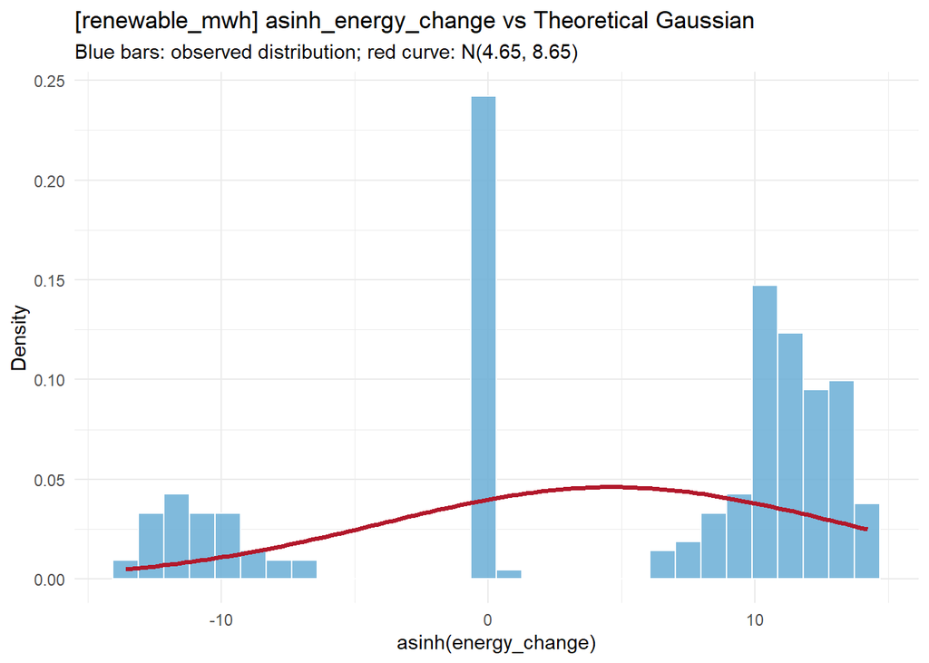

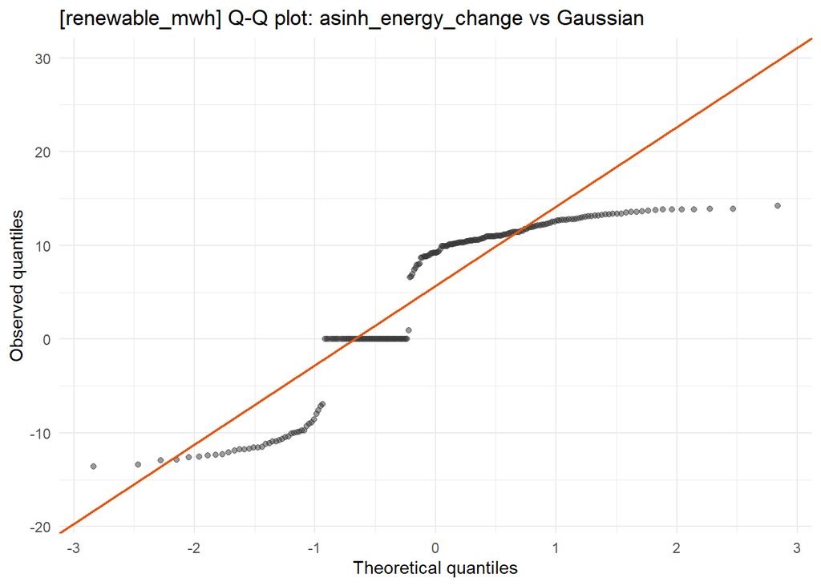

```
##
## ============================
## RESIDUALS ANALYSIS [renewable_mwh]
## ============================
## Residuals mean = 0
## Residuals sd = 8.1526
## Shapiro-Wilk p-value (residuals): 1.651e-09
```

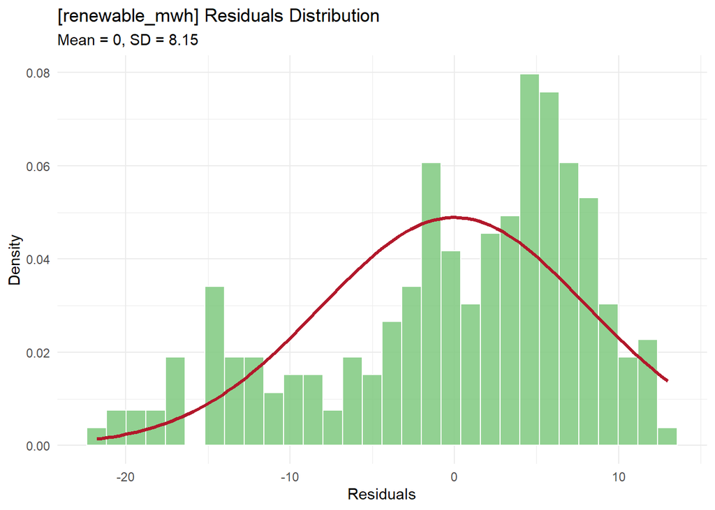

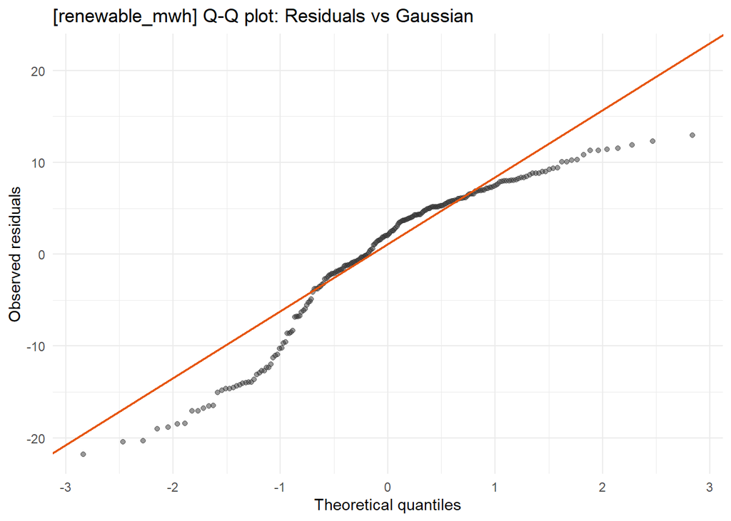

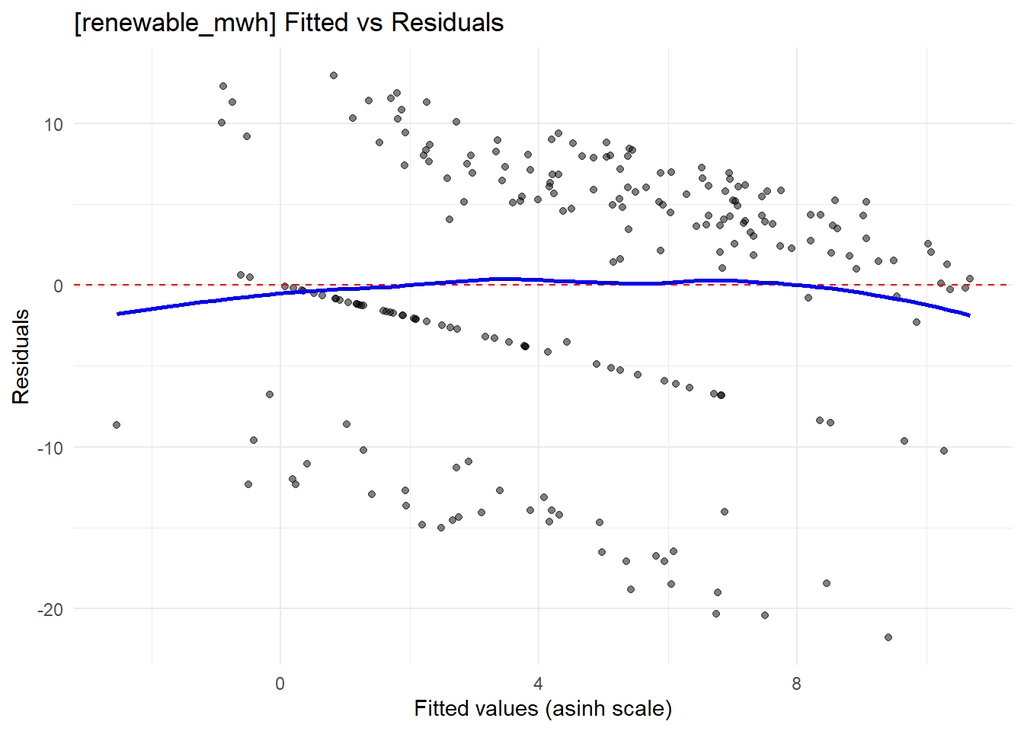

```
##
## ============================
## ASINH_ENERGY_CHANGE DISTRIBUTION [co2_tons]
## ============================
## n = 220
## Observed mean = -1.333
## Observed sd = 9.939
## Shapiro-Wilk p-value (observed): 6.806e-11
```

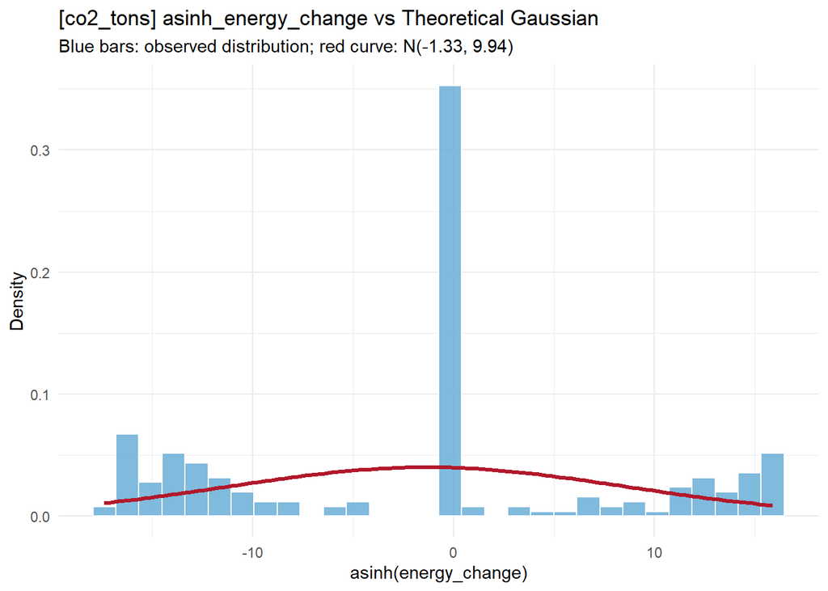

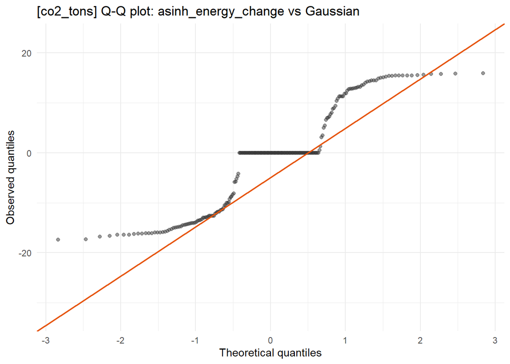

```
##
## ============================
## RESIDUALS ANALYSIS [co2_tons]
## ============================
## Residuals mean = 0
## Residuals sd = 9.4622
## Shapiro-Wilk p-value (residuals): 1.289e-05
```

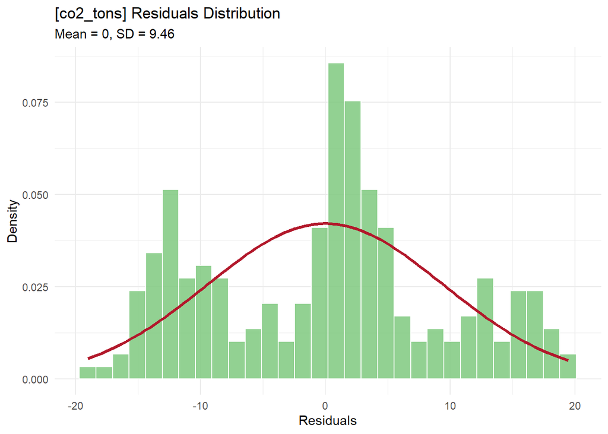

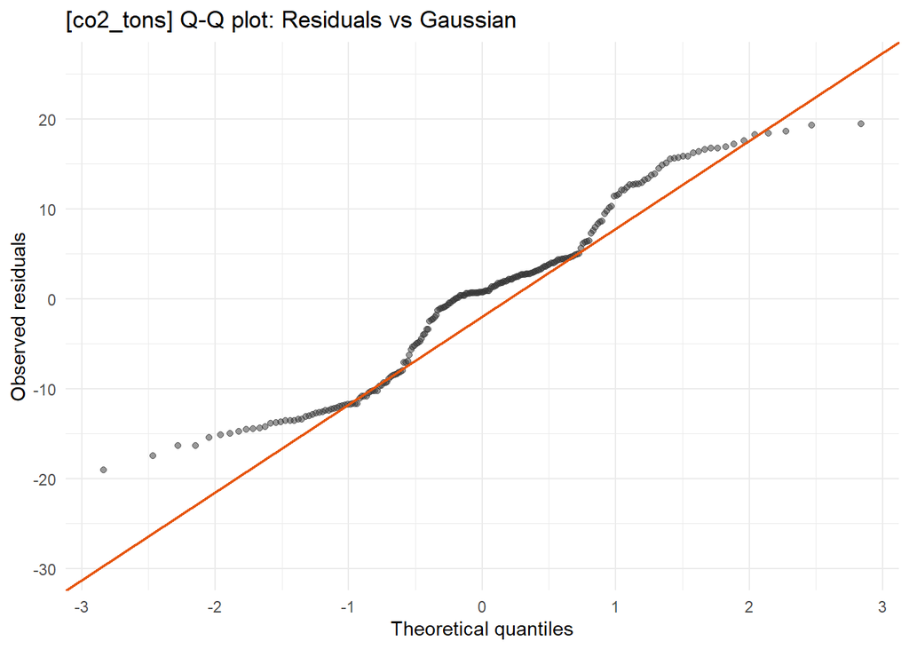

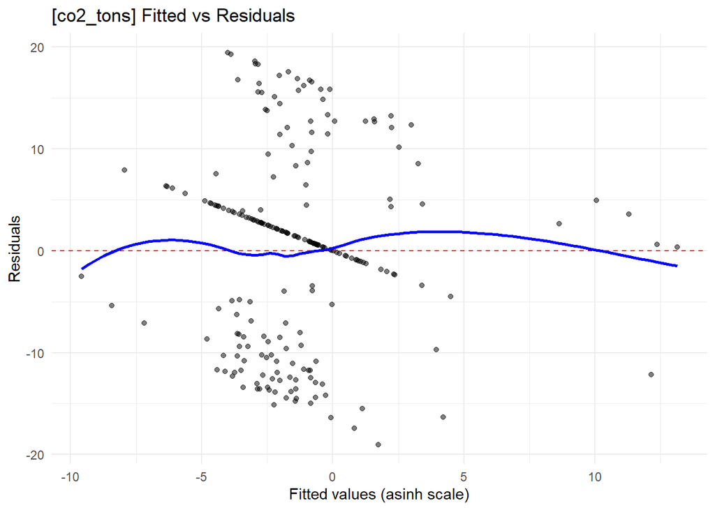

```
##
## ============================
## ASINH_ENERGY_CHANGE DISTRIBUTION [COAL]
## ============================
## n = 220
## Observed mean = -3.7983
## Observed sd = 7.2832
## Shapiro-Wilk p-value (observed): 2.012e-18
```

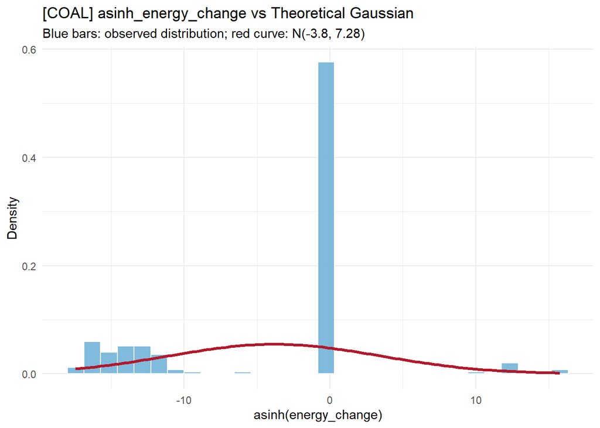

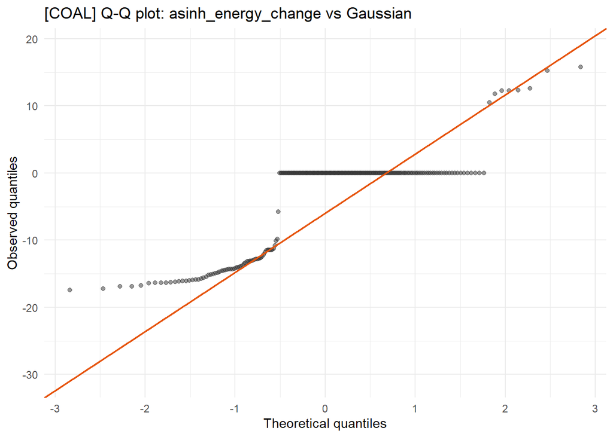

```
##
## ============================
## RESIDUALS ANALYSIS [COAL]
## ============================
## Residuals mean = 0
## Residuals sd = 6.7797
## Shapiro-Wilk p-value (residuals): 3.065e-07
```

[3 more figures not shown]

```r
walk(energy_vars, function(ev) {
  # Get model_df from analysis_county_energy_by_var (recreate minimal needed data)
  model_df <- analysis_county_energy_by_var[[ev]] |>
    left_join(
      geography_df |> select(fips, state),
      by = "fips"
    ) |>
    left_join(
      county_cbsa |>
        transmute(
          fips,
          cbsa_factor = case_when(
            cbsa_type == "Metropolitan" ~ "Metropolitan",
            cbsa_type == "Micropolitan" ~ "Micropolitan",
            TRUE ~ "Rural"
          )
        ),
      by = "fips"
    ) |>
    left_join(
      partisan_join |> transmute(fips, partisan_index_rep = as.numeric(PARTISAN_INDEX_REP)),
      by = "fips"
    ) |>
    left_join(hasplan_df, by = "fips") |>
    mutate(
      asinh_energy_change = asinh(energy_change),
      state = factor(state),
      cbsa_factor = factor(cbsa_factor, levels = c("Metropolitan", "Micropolitan", "Rural"))
    ) |>
    drop_na(asinh_energy_change, median_income_aligned, median_income_change,
            partisan_index_rep, state, cbsa_factor, hasplan_score)

  model_df <- model_df |>
    mutate(
      z_median_income_aligned = as.numeric(scale(median_income_aligned)),
      z_median_income_change = as.numeric(scale(median_income_change)),
      z_partisan_index_rep = as.numeric(scale(partisan_index_rep))
    ) |>
    drop_na(z_median_income_aligned, z_median_income_change, z_partisan_index_rep)

  # Fit the same model as chunk 10
  lm_formula <- asinh_energy_change ~
    z_median_income_aligned +
    z_median_income_change +
    z_partisan_index_rep +
    state +
    cbsa_factor +
    hasplan_score

  lm_fit <- lm(lm_formula, data = model_df)

  # Calculate residuals
  model_df$residuals <- residuals(lm_fit)
  model_df$fitted <- fitted(lm_fit)

  # Observed asinh_energy_change stats
  mu_hat <- mean(model_df$asinh_energy_change, na.rm = TRUE)
  sigma_hat <- sd(model_df$asinh_energy_change, na.rm = TRUE)

  cat("\n============================\n")
  cat("ASINH_ENERGY_CHANGE DISTRIBUTION [", ev, "]\n", sep = "")
  cat("============================\n")
  cat("n =", nrow(model_df), "\n")
  cat("Observed mean =", round(mu_hat, 4), "\n")
  cat("Observed sd =", round(sigma_hat, 4), "\n")

  # Shapiro-Wilk test (if n <= 5000)
  if (nrow(model_df) >= 3 && nrow(model_df) <= 5000) {
    shapiro_obs <- shapiro.test(model_df$asinh_energy_change)
    cat("Shapiro-Wilk p-value (observed):", signif(shapiro_obs$p.value, 4), "\n")
  } else {
    cat("Shapiro-Wilk skipped (requires 3 <= n <= 5000)\n")
  }

  # Histogram: observed vs theoretical Gaussian
  print(
    ggplot(model_df, aes(x = asinh_energy_change)) +
      geom_histogram(
        aes(y = after_stat(density)),
        bins = 30,
        fill = "#6AAED6",
        color = "white",
        alpha = 0.85
      ) +
      stat_function(
        fun = dnorm,
        args = list(mean = mu_hat, sd = sigma_hat),
        color = "#B2182B",
        linewidth = 1.2
      ) +
      labs(
        title = paste0("[", ev, "] asinh_energy_change vs Theoretical Gaussian"),
        subtitle = paste0("Blue bars: observed distribution; red curve: N(", round(mu_hat, 2), ", ", round(sigma_hat, 2), ")"),
        x = "asinh(energy_change)",
        y = "Density"
      ) +
      theme_minimal()
  )

  # Q-Q plot for observed
  print(
    ggplot(model_df, aes(sample = asinh_energy_change)) +
      stat_qq(alpha = 0.5, color = "#333333") +
      stat_qq_line(color = "#E6550D", linewidth = 0.8) +
      labs(
        title = paste0("[", ev, "] Q-Q plot: asinh_energy_change vs Gaussian"),
        x = "Theoretical quantiles",
        y = "Observed quantiles"
      ) +
      theme_minimal()
  )

  # Residuals analysis
  cat("\n============================\n")
  cat("RESIDUALS ANALYSIS [", ev, "]\n", sep = "")
  cat("============================\n")
  cat("Residuals mean =", round(mean(model_df$residuals), 6), "\n")
  cat("Residuals sd =", round(sd(model_df$residuals), 4), "\n")

  # Shapiro-Wilk on residuals
  if (nrow(model_df) >= 3 && nrow(model_df) <= 5000) {
    shapiro_resid <- shapiro.test(model_df$residuals)
    cat("Shapiro-Wilk p-value (residuals):", signif(shapiro_resid$p.value, 4), "\n")
  }

  # Histogram of residuals
  print(
    ggplot(model_df, aes(x = residuals)) +
      geom_histogram(
        aes(y = after_stat(density)),
        bins = 30,
        fill = "#7FC97F",
        color = "white",
        alpha = 0.85
      ) +
      stat_function(
        fun = dnorm,
        args = list(mean = 0, sd = sd(model_df$residuals)),
        color = "#B2182B",
        linewidth = 1.2
      ) +
      labs(
        title = paste0("[", ev, "] Residuals Distribution"),
        subtitle = paste0("Mean = 0, SD = ", round(sd(model_df$residuals), 2)),
        x = "Residuals",
        y = "Density"
      ) +
      theme_minimal()
  )

  # Q-Q plot for residuals
  print(
    ggplot(model_df, aes(sample = residuals)) +
      stat_qq(alpha = 0.5, color = "#333333") +
      stat_qq_line(color = "#E6550D", linewidth = 0.8) +
      labs(
        title = paste0("[", ev, "] Q-Q plot: Residuals vs Gaussian"),
        x = "Theoretical quantiles",
        y = "Observed residuals"
      ) +
      theme_minimal()
  )

  # Fitted vs Residuals plot
  print(
    ggplot(model_df, aes(x = fitted, y = residuals)) +
      geom_point(alpha = 0.5) +
      geom_hline(yintercept = 0, linetype = "dashed", color = "red") +
      geom_smooth(method = "loess", se = FALSE, color = "blue") +
      labs(
        title = paste0("[", ev, "] Fitted vs Residuals"),
        x = "Fitted values (asinh scale)",
        y = "Residuals"
      ) +
      theme_minimal()
  )
})
```